# DATA624-HW6-ARIMA

FPP-Hyndman exercises 8.1, 8.2, 8.3, 8.5, 8.6, 8.7.

Michael Y.

3/22/2020

```r
library(fpp2)
library(tseries)
library(urca)
```

# Homework 6 - ARIMA

Do the exercises 8.1, 8.2, 8.3, 8.5., 8.6, 8.7 in Hyndman.  
Please submit both your Rpubs link as well as attach the .rmd file with your code.

## 8.1 Figure 8.31 shows the ACFs for 36 random numbers, 360 random numbers and 1,000 random numbers.

### a) Explain the differences among these figures. Do they all indicate that the data are white noise?

The figures indicate that the data are white noise because the ACF plots appear to fall inside the critical bands (though for X2, some of the extreme points might be touching the bands.)

### b) Why are the critical values at different distances from the mean of zero?

#### Why are the autocorrelations different in each figure when they each refer to white noise?

Because it is white noise, there should be no discernable pattern. The values on each lag fall below the critical values, which differ based upon the amount of data.

## 8.2 A classic example of a non-stationary series is the daily closing IBM stock price series (data set `ibmclose`).

### Use R to plot the daily closing prices for IBM stock and the ACF and PACF.

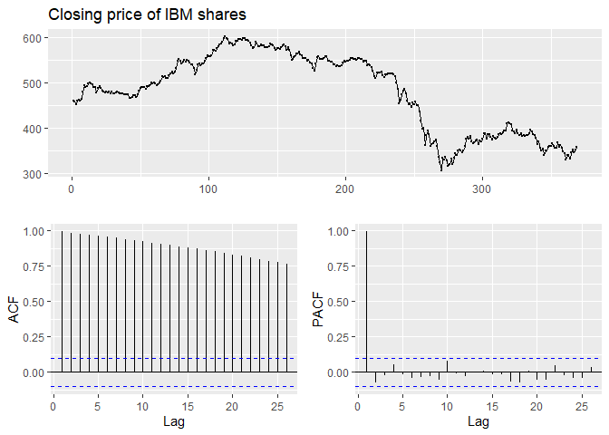

```r
ggtsdisplay(ibmclose, main="Closing price of IBM shares")
```

### Explain how each plot shows that the series is non-stationary and should be differenced.

The ACF plot indicates very high autocorrelation values, well above the critical value. Thus is because, barring unusual market behavior, the absolute price of a stock tomorrow is somewhat close to the price today (lag 1), and a bit less close on each succeeding day (higher lags.) This is why the ACF values are all high, and slowly declining.

What is interesting in finance is whether the price of the stock will go up or go down from one day to the next. Thus, the net change (which is obrainable by differencing) will result in a series which does not exhibit the strong autocorrelation as the raw price series.

Because the first lag on the PACF chart is nearly 1, this indicates a non-stationary process which should be differenced in order to obtain a stationarity.

#### Check estimated number of differences needed:

```r
ibmclose_ndiffs <- ndiffs(ibmclose)
print(paste("Number of differences suggested for ibmclose:", ibmclose_ndiffs))
```

```
## [1] "Number of differences suggested for ibmclose: 1"
```

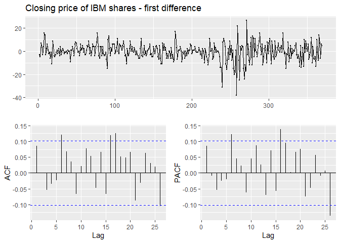

```r
ggtsdisplay(diff(ibmclose),
            main="Closing price of IBM shares - first difference")
```

Stationarity can be achieved through such differencing. Sometimes only a single difference is necessary; sometimes additional differencing is required.

We can see that we are now close to achieving stationarity because the lags on the ACF and PACF plots are inside the critical value bands (narrowly exceeding in in a few cases.)

## 8.3 For the following series, find an appropriate Box-Cox transformation and order of differencing in order to obtain stationary data.

### a) **usnetelec**

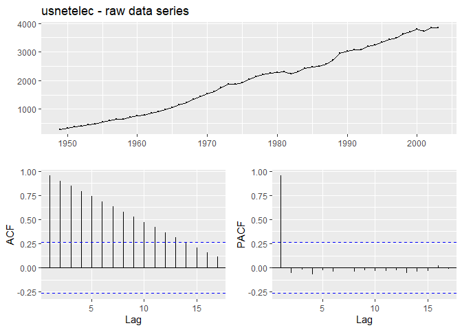

```r
ggtsdisplay(usnetelec, main = "usnetelec - raw data series")
```

#### Ljung-box test on raw data series:

```r
Box.test(usnetelec, type = "Ljung-Box")
```

```
##
##  Box-Ljung test
##
## data:  usnetelec
## X-squared = 52.549, df = 1, p-value = 4.196e-13
```

Because the p-value is low, the Null hypothesis is REJECTED in factor of the alternative (Autocorrelation exists.)

#### Try Box-Cox transformation:

```r
usnetelec_lambda <- round(BoxCox.lambda(usnetelec),5)
print(paste("Lambda for usnetelec: ", usnetelec_lambda))
```

```
## [1] "Lambda for usnetelec:  0.51677"
```

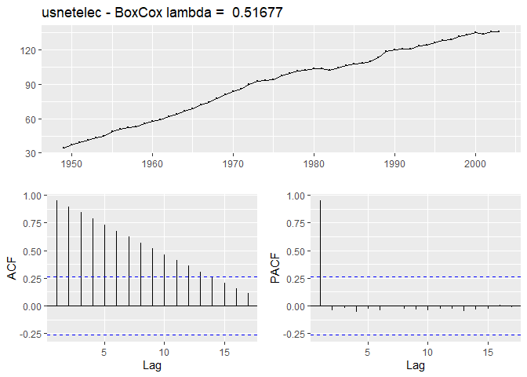

```r
usnetelec_BC <- BoxCox(usnetelec, usnetelec_lambda)

ggtsdisplay(usnetelec_BC, main = paste("usnetelec - BoxCox lambda = ",
                                       usnetelec_lambda))
```

The graph of the Box-Cox transformed data shows strong autocorrelation.

```r
Box.test(usnetelec_BC, type = "Ljung-Box")
```

```
##
##  Box-Ljung test
##
## data:  usnetelec_BC
## X-squared = 52.191, df = 1, p-value = 5.035e-13
```

Because the p-value is still low, the Null hypothesis is again REJECTED in factor of the alternative (Autocorrelation exists.)

#### Check estimated number of differences needed:

```r
usnetelec_BC_ndiffs <- ndiffs(usnetelec_BC)
print(paste("Number of differences suggested for usnetelec_BC:", usnetelec_BC_ndiffs))
```

```
## [1] "Number of differences suggested for usnetelec_BC: 2"
```

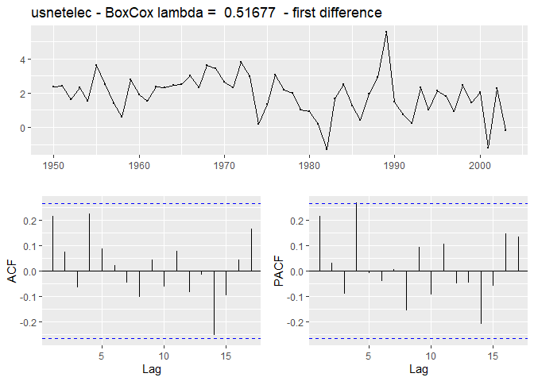

```r
ggtsdisplay(diff(usnetelec_BC), main=paste("usnetelec - BoxCox lambda = ",
                                           usnetelec_lambda," - first difference"))
```

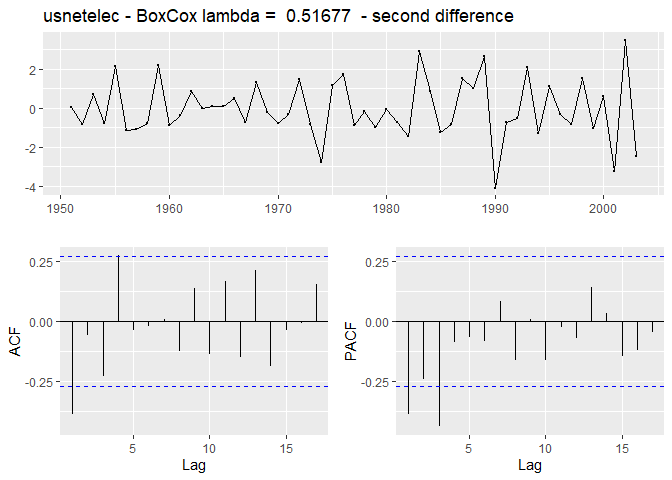

```r
ggtsdisplay(diff(diff(usnetelec_BC)), main=paste("usnetelec - BoxCox lambda = ",
                                                 usnetelec_lambda," - second difference"))
```

#### Although the result from “ndiffs” estimates that 2 differences are required, the results from a single difference look better.

#### Let’s test first differencing:

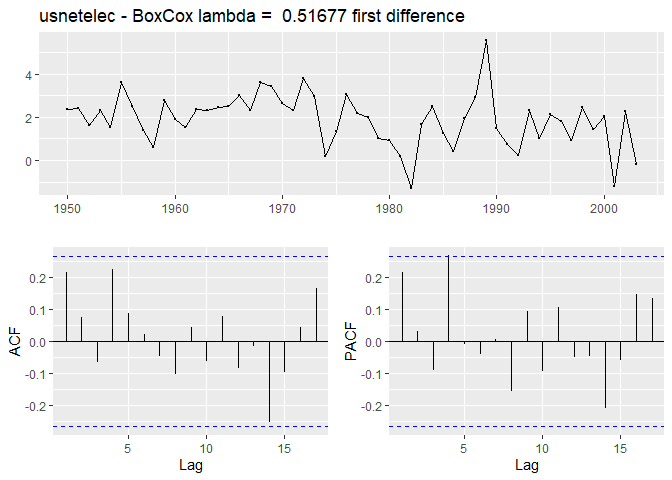

```r
#### Diff data series
usnetelec_BC %>% diff() -> usnetelec_BC_d1
ggtsdisplay(usnetelec_BC_d1, main = paste("usnetelec - BoxCox lambda = ",
                                          usnetelec_lambda, "first difference"))
```

```r
#### Ljung-box test:
Box.test(usnetelec_BC_d1, type = "Ljung-Box")
```

```
##
##  Box-Ljung test
##
## data:  usnetelec_BC_d1
## X-squared = 2.6132, df = 1, p-value = 0.106
```

Because the p-value is high, we FAIL TO REJECT the null hypothesis, which is that the data are independent (i.e., no serial correlation.) So, first-differenced usnetelec data can be thought of as a white noise series.

#### Kwiatkowski-Phillips-Schmidt-Shin (KPSS) test:

```r
library(tseries)


#### Test raw data series
kpss.test(usnetelec, "Level", lshort = F)
```

```
##
##  KPSS Test for Level Stationarity
##
## data:  usnetelec
## KPSS Level = 0.6153, Truncation lag parameter = 10, p-value = 0.02125
```

```r
kpss.test(usnetelec, "Trend", lshort = F)
```

```
##
##  KPSS Test for Trend Stationarity
##
## data:  usnetelec
## KPSS Trend = 0.098058, Truncation lag parameter = 10, p-value = 0.1
```

```r
usnetelec %>% ur.kpss(type="mu", lags="long") %>% summary()
```

```
##
## #######################
## # KPSS Unit Root Test #
## #######################
##
## Test is of type: mu with 10 lags.
##
## Value of test-statistic is: 0.6153
##
## Critical value for a significance level of:
##                 10pct  5pct 2.5pct  1pct
## critical values 0.347 0.463  0.574 0.739
```

```r
usnetelec %>% ur.kpss(type="tau", lags="long") %>% summary()
```

```
##
## #######################
## # KPSS Unit Root Test #
## #######################
##
## Test is of type: tau with 10 lags.
##
## Value of test-statistic is: 0.0981
##
## Critical value for a significance level of:
##                 10pct  5pct 2.5pct  1pct
## critical values 0.119 0.146  0.176 0.216
```

##### KPSS Level Test fails on raw data series; Trend test passes

#### Test Box-Cox transform:

```r
kpss.test(usnetelec_BC, "Level", lshort = F)
```

```
##
##  KPSS Test for Level Stationarity
##
## data:  usnetelec_BC
## KPSS Level = 0.61487, Truncation lag parameter = 10, p-value = 0.02128
```

```r
kpss.test(usnetelec_BC, "Trend", lshort = F)
```

```
##
##  KPSS Test for Trend Stationarity
##
## data:  usnetelec_BC
## KPSS Trend = 0.15177, Truncation lag parameter = 10, p-value = 0.04519
```

```r
usnetelec_BC %>% ur.kpss(type="mu", lags="long") %>% summary()
```

```
##
## #######################
## # KPSS Unit Root Test #
## #######################
##
## Test is of type: mu with 10 lags.
##
## Value of test-statistic is: 0.6149
##
## Critical value for a significance level of:
##                 10pct  5pct 2.5pct  1pct
## critical values 0.347 0.463  0.574 0.739
```

```r
usnetelec_BC %>% ur.kpss(type="tau", lags="long") %>% summary()
```

```
##
## #######################
## # KPSS Unit Root Test #
## #######################
##
## Test is of type: tau with 10 lags.
##
## Value of test-statistic is: 0.1518
##
## Critical value for a significance level of:
##                 10pct  5pct 2.5pct  1pct
## critical values 0.119 0.146  0.176 0.216
```

##### Both KPSS tests fail on Box Cox transformed data series.

#### Test first difference:

```r
kpss.test(usnetelec_BC_d1, "Level", lshort = F)
```

```
##
##  KPSS Test for Level Stationarity
##
## data:  usnetelec_BC_d1
## KPSS Level = 0.33954, Truncation lag parameter = 10, p-value = 0.1
```

```r
kpss.test(usnetelec_BC_d1, "Trend", lshort = F)
```

```
##
##  KPSS Test for Trend Stationarity
##
## data:  usnetelec_BC_d1
## KPSS Trend = 0.074231, Truncation lag parameter = 10, p-value = 0.1
```

```r
usnetelec_BC_d1 %>% ur.kpss(type="mu", lags="long") %>% summary()
```

```
##
## #######################
## # KPSS Unit Root Test #
## #######################
##
## Test is of type: mu with 10 lags.
##
## Value of test-statistic is: 0.3395
##
## Critical value for a significance level of:
##                 10pct  5pct 2.5pct  1pct
## critical values 0.347 0.463  0.574 0.739
```

```r
usnetelec_BC_d1 %>% ur.kpss(type="tau", lags="long") %>% summary()
```

```
##
## #######################
## # KPSS Unit Root Test #
## #######################
##
## Test is of type: tau with 10 lags.
##
## Value of test-statistic is: 0.0742
##
## Critical value for a significance level of:
##                 10pct  5pct 2.5pct  1pct
## critical values 0.119 0.146  0.176 0.216
```

##### Both KPSS tests pass on first-differenced data series, confirming that second-differencing is not required.

### b) **usgdp**

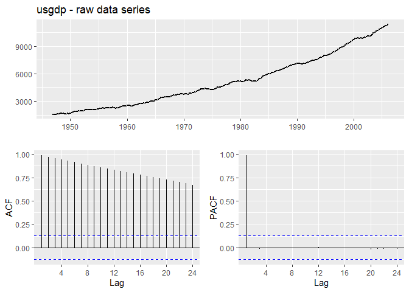

```r
ggtsdisplay(usgdp, main = "usgdp - raw data series")
```

```r
# The graph of the raw data shows strong autocorrelation.
```

#### Ljung-box test on raw data series:

```r
Box.test(usgdp, type = "Ljung-Box")
```

```
##
##  Box-Ljung test
##
## data:  usgdp
## X-squared = 233.07, df = 1, p-value < 2.2e-16
```

Because the p-value is low, the Null hypothesis is REJECTED in factor of the alternative (Autocorrelation exists.)

#### Try Box-Cox transformation:

```r
usgdp_lambda <- round(BoxCox.lambda(usgdp),5)
print(paste("Lambda for usgdp: ", usgdp_lambda))
```

```
## [1] "Lambda for usgdp:  0.36635"
```

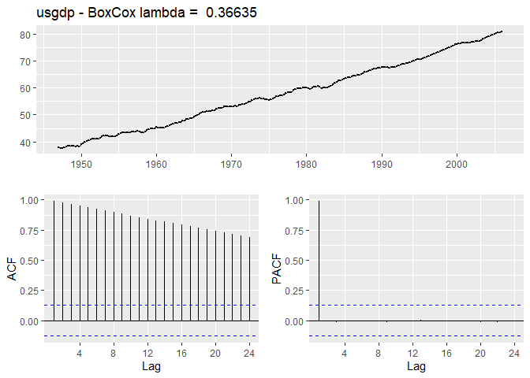

```r
usgdp_BC <- BoxCox(usgdp, usgdp_lambda)

ggtsdisplay(usgdp_BC, main = paste("usgdp - BoxCox lambda = ",usgdp_lambda))
```

The graph of the Box-Cox transformed data shows strong autocorrelation.

```r
Box.test(usgdp_BC, type = "Ljung-Box")
```

```
##
##  Box-Ljung test
##
## data:  usgdp_BC
## X-squared = 233.76, df = 1, p-value < 2.2e-16
```

Because the p-value is still low, the Null hypothesis is again REJECTED in factor of the alternative (Autocorrelation exists.)

#### Check estimated number of differences needed:

```r
usgdp_nsdiffs <- nsdiffs(usgdp)
print(paste("Number of SEASONAL differences suggested for usgdp (raw data):", usgdp_nsdiffs))
```

```
## [1] "Number of SEASONAL differences suggested for usgdp (raw data): 0"
```

```r
usgdp_ndiffs <- ndiffs(usgdp)
print(paste("Number of differences suggested for usgdp (raw data):", usgdp_ndiffs))
```

```
## [1] "Number of differences suggested for usgdp (raw data): 2"
```

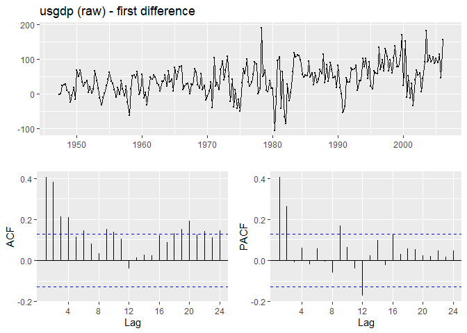

```r
ggtsdisplay(diff(usgdp), main=paste("usgdp (raw) - first difference"))
```

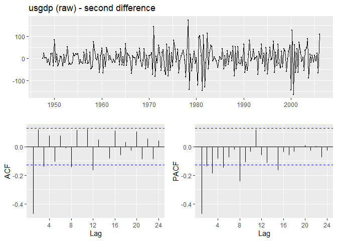

```r
ggtsdisplay(diff(diff(usgdp)), main=paste("usgdp (raw) - second difference"))
```

#### Check differences estimated for the Box-Cox transformed series:

```r
usgdp_BC_nsdiffs <- nsdiffs(usgdp_BC)
print(paste("Number of SEASONAL differences suggested for usgdp_BC:", usgdp_BC_nsdiffs))
```

```
## [1] "Number of SEASONAL differences suggested for usgdp_BC: 0"
```

```r
usgdp_BC_ndiffs <- ndiffs(usgdp_BC)
print(paste("Number of differences suggested for usgdp_BC:", usgdp_BC_ndiffs))
```

```
## [1] "Number of differences suggested for usgdp_BC: 1"
```

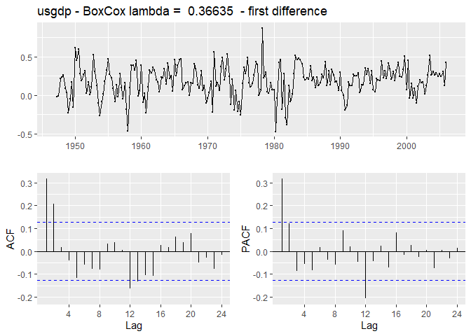

```r
ggtsdisplay(diff(usgdp_BC), main=paste("usgdp - BoxCox lambda = ",
                                       usgdp_lambda," - first difference"))
```

The “nsdiffs” and “ndiffs” functions suggest that no seasonal differencing is required, while the raw data series requires 2 diffs and the Box-Cox transformed series requires 1 diff. However, the plots do not agree, as there still appears to be evidence of autocorrelation.

In particular, there does seem to be autocorrelation at lag 12, suggesting that seasonality does exist.

#### Have a look at second differences:

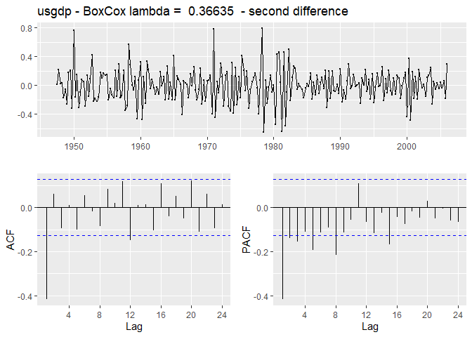

```r
ggtsdisplay(diff(diff(usgdp_BC)), main=paste("usgdp - BoxCox lambda = ",
                                             usgdp_lambda," - second difference"))
```

This shows autocorrelation, too.

#### Let’s evaluate first differencing:

#### Diff data series:

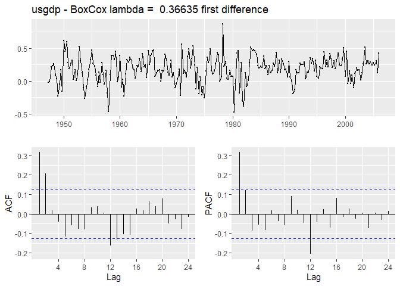

```r
usgdp_BC %>% diff() -> usgdp_BC_d1
ggtsdisplay(usgdp_BC_d1, main = paste("usgdp - BoxCox lambda = ",
                                      usgdp_lambda, "first difference"))
```

The first differenced series shows autocorrelation on lags 1, 2, 12

#### Ljung-box test:

```r
Box.test(usgdp_BC_d1, type = "Ljung-Box")
```

```
##
##  Box-Ljung test
##
## data:  usgdp_BC_d1
## X-squared = 23.874, df = 1, p-value = 1.029e-06
```

Because the p-value is low, the Null hypothesis is REJECTED in factor of the alternative (Autocorrelation exists.)

#### Let’s try second differencing:

#### Diff data series again

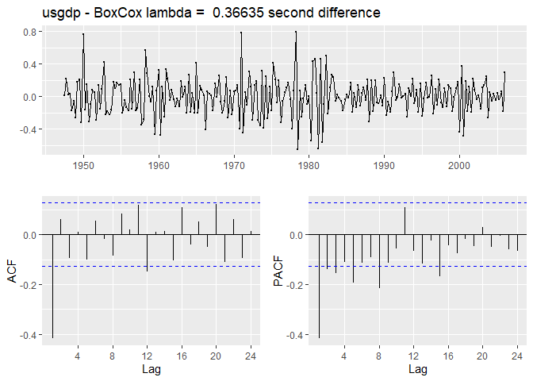

```r
usgdp_BC_d1 %>% diff() -> usgdp_BC_d2
ggtsdisplay(usgdp_BC_d2, main = paste("usgdp - BoxCox lambda = ",
                                      usgdp_lambda, "second difference"))
```

#### Ljung-box test:

```r
Box.test(usgdp_BC_d2, type = "Ljung-Box")
```

```
##
##  Box-Ljung test
##
## data:  usgdp_BC_d2
## X-squared = 41.715, df = 1, p-value = 1.056e-10
```

Because the p-value is low, the Null hypothesis is again REJECTED in factor of the alternative (Autocorrelation exists.)

#### Let’s try third differencing:

#### Diff data series again:

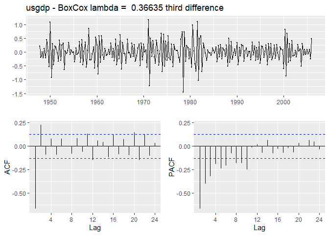

```r
usgdp_BC_d2 %>% diff() -> usgdp_BC_d3
ggtsdisplay(usgdp_BC_d3, main = paste("usgdp - BoxCox lambda = ",
                                      usgdp_lambda, "third difference"))
```

The third differenced series still shows some autocorrelation

#### Ljung-box test:

```r
Box.test(usgdp_BC_d3, type = "Ljung-Box")
```

```
##
##  Box-Ljung test
##
## data:  usgdp_BC_d3
## X-squared = 105.37, df = 1, p-value < 2.2e-16
```

Because the p-value is low, the Null hypothesis is again REJECTED in factor of the alternative (Autocorrelation exists.)

#### Kwiatkowski-Phillips-Schmidt-Shin (KPSS) test:

```r
kpss.test(usgdp, "Level", lshort = F)
```

```
##
##  KPSS Test for Level Stationarity
##
## data:  usgdp
## KPSS Level = 1.6321, Truncation lag parameter = 14, p-value = 0.01
```

```r
kpss.test(usgdp, "Trend", lshort = F)
```

```
##
##  KPSS Test for Trend Stationarity
##
## data:  usgdp
## KPSS Trend = 0.39501, Truncation lag parameter = 14, p-value = 0.01
```

```r
usgdp %>% ur.kpss(type="mu", lags="long") %>% summary()
```

```
##
## #######################
## # KPSS Unit Root Test #
## #######################
##
## Test is of type: mu with 14 lags.
##
## Value of test-statistic is: 1.6321
##
## Critical value for a significance level of:
##                 10pct  5pct 2.5pct  1pct
## critical values 0.347 0.463  0.574 0.739
```

```r
usgdp %>% ur.kpss(type="tau", lags="long") %>% summary()
```

```
##
## #######################
## # KPSS Unit Root Test #
## #######################
##
## Test is of type: tau with 14 lags.
##
## Value of test-statistic is: 0.395
##
## Critical value for a significance level of:
##                 10pct  5pct 2.5pct  1pct
## critical values 0.119 0.146  0.176 0.216
```

##### Both KPSS tests fail on raw data series

```r
kpss.test(usgdp_BC, "Level", lshort = F)
```

```
##
##  KPSS Test for Level Stationarity
##
## data:  usgdp_BC
## KPSS Level = 1.68, Truncation lag parameter = 14, p-value = 0.01
```

```r
kpss.test(usgdp_BC, "Trend", lshort = F)
```

```
##
##  KPSS Test for Trend Stationarity
##
## data:  usgdp_BC
## KPSS Trend = 0.24107, Truncation lag parameter = 14, p-value = 0.01
```

```r
usgdp_BC %>% ur.kpss(type="mu", lags="long") %>% summary()
```

```
##
## #######################
## # KPSS Unit Root Test #
## #######################
##
## Test is of type: mu with 14 lags.
##
## Value of test-statistic is: 1.68
##
## Critical value for a significance level of:
##                 10pct  5pct 2.5pct  1pct
## critical values 0.347 0.463  0.574 0.739
```

```r
usgdp_BC %>% ur.kpss(type="tau", lags="long") %>% summary()
```

```
##
## #######################
## # KPSS Unit Root Test #
## #######################
##
## Test is of type: tau with 14 lags.
##
## Value of test-statistic is: 0.2411
##
## Critical value for a significance level of:
##                 10pct  5pct 2.5pct  1pct
## critical values 0.119 0.146  0.176 0.216
```

##### Both KPSS tests fail on Box Cox transformed data series

```r
kpss.test(usgdp_BC_d1, "Level", lshort = F)
```

```
##
##  KPSS Test for Level Stationarity
##
## data:  usgdp_BC_d1
## KPSS Level = 0.23949, Truncation lag parameter = 14, p-value = 0.1
```

```r
kpss.test(usgdp_BC_d1, "Trend", lshort = F)
```

```
##
##  KPSS Test for Trend Stationarity
##
## data:  usgdp_BC_d1
## KPSS Trend = 0.034928, Truncation lag parameter = 14, p-value = 0.1
```

```r
usgdp_BC_d1 %>% ur.kpss(type="mu", lags="long") %>% summary()
```

```
##
## #######################
## # KPSS Unit Root Test #
## #######################
##
## Test is of type: mu with 14 lags.
##
## Value of test-statistic is: 0.2395
##
## Critical value for a significance level of:
##                 10pct  5pct 2.5pct  1pct
## critical values 0.347 0.463  0.574 0.739
```

```r
usgdp_BC_d1 %>% ur.kpss(type="tau", lags="long") %>% summary()
```

```
##
## #######################
## # KPSS Unit Root Test #
## #######################
##
## Test is of type: tau with 14 lags.
##
## Value of test-statistic is: 0.0349
##
## Critical value for a significance level of:
##                 10pct  5pct 2.5pct  1pct
## critical values 0.119 0.146  0.176 0.216
```

##### Both KPSS tests pass on first differenced data series

```r
kpss.test(usgdp_BC_d2, "Level", lshort = F)
```

```
##
##  KPSS Test for Level Stationarity
##
## data:  usgdp_BC_d2
## KPSS Level = 0.035084, Truncation lag parameter = 14, p-value = 0.1
```

```r
kpss.test(usgdp_BC_d2, "Trend", lshort = F)
```

```
##
##  KPSS Test for Trend Stationarity
##
## data:  usgdp_BC_d2
## KPSS Trend = 0.034844, Truncation lag parameter = 14, p-value = 0.1
```

```r
usgdp_BC_d2 %>% ur.kpss(type="mu", lags="long") %>% summary()
```

```
##
## #######################
## # KPSS Unit Root Test #
## #######################
##
## Test is of type: mu with 14 lags.
##
## Value of test-statistic is: 0.0351
##
## Critical value for a significance level of:
##                 10pct  5pct 2.5pct  1pct
## critical values 0.347 0.463  0.574 0.739
```

```r
usgdp_BC_d2 %>% ur.kpss(type="tau", lags="long") %>% summary()
```

```
##
## #######################
## # KPSS Unit Root Test #
## #######################
##
## Test is of type: tau with 14 lags.
##
## Value of test-statistic is: 0.0348
##
## Critical value for a significance level of:
##                 10pct  5pct 2.5pct  1pct
## critical values 0.119 0.146  0.176 0.216
```

##### Both KPSS tests pass on second differenced data series

```r
kpss.test(usgdp_BC_d3, "Level", lshort = F)
```

```
##
##  KPSS Test for Level Stationarity
##
## data:  usgdp_BC_d3
## KPSS Level = 0.043205, Truncation lag parameter = 14, p-value = 0.1
```

```r
kpss.test(usgdp_BC_d3, "Trend", lshort = F)
```

```
##
##  KPSS Test for Trend Stationarity
##
## data:  usgdp_BC_d3
## KPSS Trend = 0.03361, Truncation lag parameter = 14, p-value = 0.1
```

```r
usgdp_BC_d3 %>% ur.kpss(type="mu", lags="long") %>% summary()
```

```
##
## #######################
## # KPSS Unit Root Test #
## #######################
##
## Test is of type: mu with 14 lags.
##
## Value of test-statistic is: 0.0432
##
## Critical value for a significance level of:
##                 10pct  5pct 2.5pct  1pct
## critical values 0.347 0.463  0.574 0.739
```

```r
usgdp_BC_d3 %>% ur.kpss(type="tau", lags="long") %>% summary()
```

```
##
## #######################
## # KPSS Unit Root Test #
## #######################
##
## Test is of type: tau with 14 lags.
##
## Value of test-statistic is: 0.0336
##
## Critical value for a significance level of:
##                 10pct  5pct 2.5pct  1pct
## critical values 0.119 0.146  0.176 0.216
```

##### Both KPSS tests pass on third differenced data series

#### The KPSS test indicates that one difference was sufficient to make the data stationary.

### c) **mcopper**

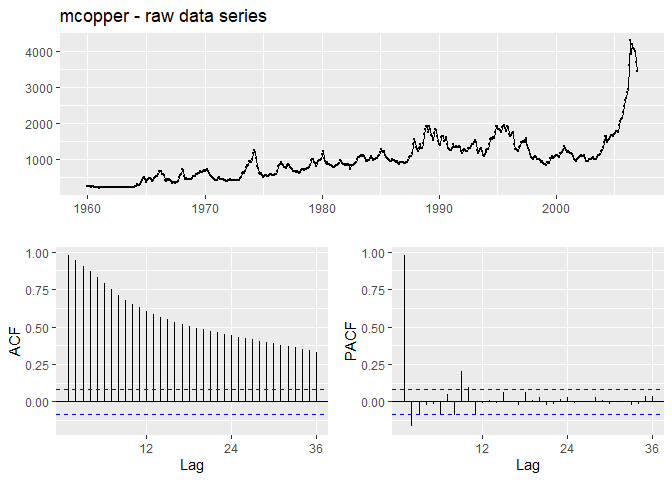

```r
ggtsdisplay(mcopper, main = "mcopper - raw data series")
```

```r
# The graph of the raw data shows strong autocorrelation.
```

#### Ljung-box test on raw data series:

```r
Box.test(mcopper, type = "Ljung-Box")
```

```
##
##  Box-Ljung test
##
## data:  mcopper
## X-squared = 539.54, df = 1, p-value < 2.2e-16
```

Because the p-value is low, the Null hypothesis is REJECTED in factor of the alternative (Autocorrelation exists.)

#### Try Box-Cox transformation:

```r
mcopper_lambda <- round(BoxCox.lambda(mcopper),5)
print(paste("Lambda for mcopper: ", mcopper_lambda))
```

```
## [1] "Lambda for mcopper:  0.1919"
```

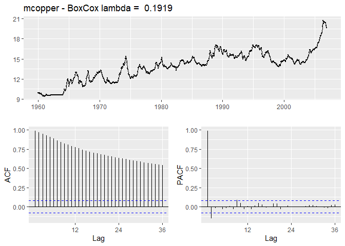

```r
mcopper_BC <- BoxCox(mcopper, mcopper_lambda)

ggtsdisplay(mcopper_BC, main = paste("mcopper - BoxCox lambda = ",mcopper_lambda))
```

The graph of the Box-Cox transformed data shows strong autocorrelation.

```r
Box.test(mcopper_BC, type = "Ljung-Box")
```

```
##
##  Box-Ljung test
##
## data:  mcopper_BC
## X-squared = 550.42, df = 1, p-value < 2.2e-16
```

Because the p-value is still low, the Null hypothesis is again REJECTED in factor of the alternative (Autocorrelation exists.)

#### Check estimated number of differences needed:

```r
mcopper_nsdiffs <- nsdiffs(mcopper)
print(paste("Number of SEASONAL differences suggested for mcopper (raw data):", mcopper_nsdiffs))
```

```
## [1] "Number of SEASONAL differences suggested for mcopper (raw data): 0"
```

```r
mcopper_ndiffs <- ndiffs(mcopper)
print(paste("Number of differences suggested for mcopper (raw data):", mcopper_ndiffs))
```

```
## [1] "Number of differences suggested for mcopper (raw data): 1"
```

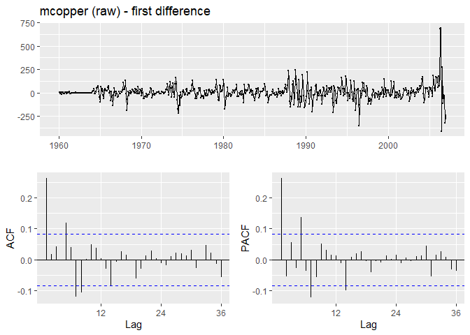

```r
ggtsdisplay(diff(mcopper), main=paste("mcopper (raw) - first difference"))
```

The graphs show that differencing without the Box-Cox transformation is not adequate to achieve stationarity.

#### Check differences estimated for the Box-Cox transformed series:

```r
mcopper_BC_nsdiffs <- nsdiffs(mcopper_BC)
print(paste("Number of SEASONAL differences suggested for mcopper_BC:", mcopper_BC_nsdiffs))
```

```
## [1] "Number of SEASONAL differences suggested for mcopper_BC: 0"
```

```r
mcopper_BC_ndiffs <- ndiffs(mcopper_BC)
print(paste("Number of differences suggested for mcopper_BC:", mcopper_BC_ndiffs))
```

```
## [1] "Number of differences suggested for mcopper_BC: 1"
```

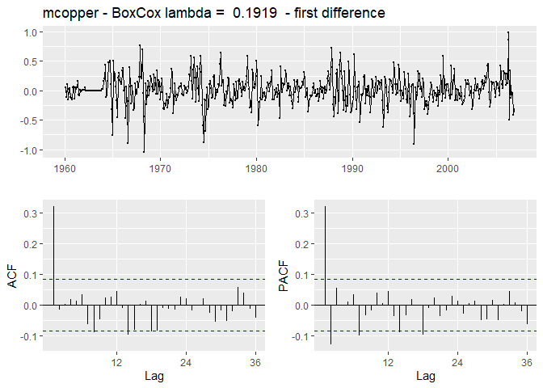

```r
ggtsdisplay(diff(mcopper_BC), main=paste("mcopper - BoxCox lambda = ",
                                       mcopper_lambda," - first difference"))
```

The “nsdiffs” and “ndiffs” functions suggest that no seasonal differencing is required. The raw data series and the Box-Cox transformed series each require 1 diff.

However, the plots do not agree, as there still appears to be evidence of autocorrelation, but the result following the Box-Cox transformation looks better.

#### Have a look at second differences:

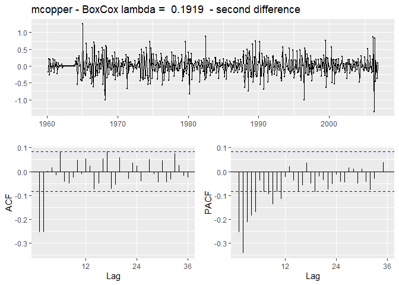

```r
ggtsdisplay(diff(diff(mcopper_BC)), main=paste("mcopper - BoxCox lambda = ",
                                             mcopper_lambda," - second difference"))
```

This looks worse than the result of first differences.

#### Let’s evaluate first differencing:

#### Diff data series:

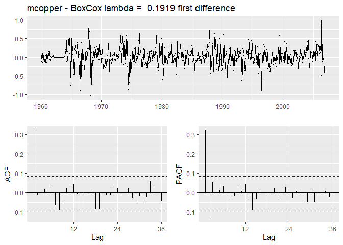

```r
mcopper_BC %>% diff() -> mcopper_BC_d1
ggtsdisplay(mcopper_BC_d1, main = paste("mcopper - BoxCox lambda = ",
                                      mcopper_lambda, "first difference"))
```

The first differenced series shows autocorrelation on lags 1, and a few of the subsequent lags breach the critical value.

#### Ljung-box test:

```r
Box.test(mcopper_BC_d1, type = "Ljung-Box")
```

```
##
##  Box-Ljung test
##
## data:  mcopper_BC_d1
## X-squared = 57.518, df = 1, p-value = 3.353e-14
```

Because the p-value is low, the Null hypothesis is REJECTED in factor of the alternative (Autocorrelation exists.)

#### Let’s try second differencing:

#### Diff data series again

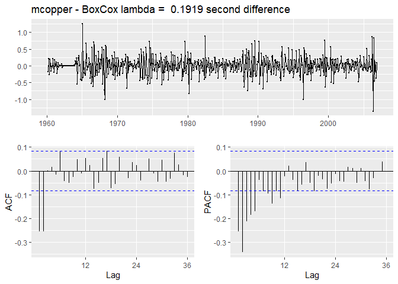

```r
mcopper_BC_d1 %>% diff() -> mcopper_BC_d2
ggtsdisplay(mcopper_BC_d2, main = paste("mcopper - BoxCox lambda = ",
                                      mcopper_lambda, "second difference"))
```

The second differenced series shows autocorrelation on lags 1 and 2

#### Ljung-box test:

```r
Box.test(mcopper_BC_d2, type = "Ljung-Box")
```

```
##
##  Box-Ljung test
##
## data:  mcopper_BC_d2
## X-squared = 37.178, df = 1, p-value = 1.078e-09
```

Because the p-value is low, the Null hypothesis is again REJECTED in factor of the alternative (Autocorrelation exists.)

#### Let’s try third differencing:

#### Diff data series again:

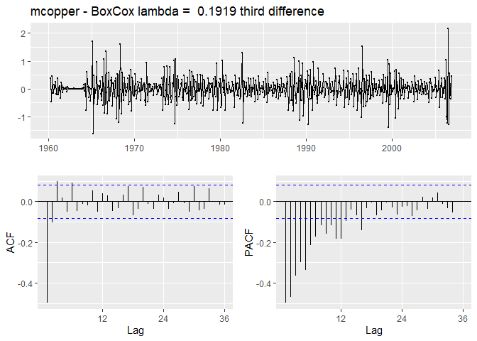

```r
mcopper_BC_d2 %>% diff() -> mcopper_BC_d3
ggtsdisplay(mcopper_BC_d3, main = paste("mcopper - BoxCox lambda = ",
                                      mcopper_lambda, "third difference"))
```

The third differenced series still shows some autocorrelation

#### Ljung-box test:

```r
Box.test(mcopper_BC_d3, type = "Ljung-Box")
```

```
##
##  Box-Ljung test
##
## data:  mcopper_BC_d3
## X-squared = 140.77, df = 1, p-value < 2.2e-16
```

Because the p-value is low, the Null hypothesis is again REJECTED in factor of the alternative (Autocorrelation exists.)

#### Kwiatkowski-Phillips-Schmidt-Shin (KPSS) test:

```r
kpss.test(mcopper, "Level", lshort = F)
```

```
##
##  KPSS Test for Level Stationarity
##
## data:  mcopper
## KPSS Level = 2.1648, Truncation lag parameter = 18, p-value = 0.01
```

```r
kpss.test(mcopper, "Trend", lshort = F)
```

```
##
##  KPSS Test for Trend Stationarity
##
## data:  mcopper
## KPSS Trend = 0.068656, Truncation lag parameter = 18, p-value = 0.1
```

```r
mcopper %>% ur.kpss(type="mu", lags="long") %>% summary()
```

```
##
## #######################
## # KPSS Unit Root Test #
## #######################
##
## Test is of type: mu with 18 lags.
##
## Value of test-statistic is: 2.1648
##
## Critical value for a significance level of:
##                 10pct  5pct 2.5pct  1pct
## critical values 0.347 0.463  0.574 0.739
```

```r
mcopper %>% ur.kpss(type="tau", lags="long") %>% summary()
```

```
##
## #######################
## # KPSS Unit Root Test #
## #######################
##
## Test is of type: tau with 18 lags.
##
## Value of test-statistic is: 0.0687
##
## Critical value for a significance level of:
##                 10pct  5pct 2.5pct  1pct
## critical values 0.119 0.146  0.176 0.216
```

##### The KPSS tests on the raw data series fail on Level, but pass on Trend

```r
kpss.test(mcopper_BC, "Level", lshort = F)
```

```
##
##  KPSS Test for Level Stationarity
##
## data:  mcopper_BC
## KPSS Level = 2.5113, Truncation lag parameter = 18, p-value = 0.01
```

```r
kpss.test(mcopper_BC, "Trend", lshort = F)
```

```
##
##  KPSS Test for Trend Stationarity
##
## data:  mcopper_BC
## KPSS Trend = 0.2472, Truncation lag parameter = 18, p-value = 0.01
```

```r
mcopper_BC %>% ur.kpss(type="mu", lags="long") %>% summary()
```

```
##
## #######################
## # KPSS Unit Root Test #
## #######################
##
## Test is of type: mu with 18 lags.
##
## Value of test-statistic is: 2.5113
##
## Critical value for a significance level of:
##                 10pct  5pct 2.5pct  1pct
## critical values 0.347 0.463  0.574 0.739
```

```r
mcopper_BC %>% ur.kpss(type="tau", lags="long") %>% summary()
```

```
##
## #######################
## # KPSS Unit Root Test #
## #######################
##
## Test is of type: tau with 18 lags.
##
## Value of test-statistic is: 0.2472
##
## Critical value for a significance level of:
##                 10pct  5pct 2.5pct  1pct
## critical values 0.119 0.146  0.176 0.216
```

##### Both KPSS tests fail on Box Cox transformed data series

```r
kpss.test(mcopper_BC_d1, "Level", lshort = F)
```

```
##
##  KPSS Test for Level Stationarity
##
## data:  mcopper_BC_d1
## KPSS Level = 0.062912, Truncation lag parameter = 18, p-value = 0.1
```

```r
kpss.test(mcopper_BC_d1, "Trend", lshort = F)
```

```
##
##  KPSS Test for Trend Stationarity
##
## data:  mcopper_BC_d1
## KPSS Trend = 0.057247, Truncation lag parameter = 18, p-value = 0.1
```

```r
mcopper_BC_d1 %>% ur.kpss(type="mu", lags="long") %>% summary()
```

```
##
## #######################
## # KPSS Unit Root Test #
## #######################
##
## Test is of type: mu with 18 lags.
##
## Value of test-statistic is: 0.0629
##
## Critical value for a significance level of:
##                 10pct  5pct 2.5pct  1pct
## critical values 0.347 0.463  0.574 0.739
```

```r
mcopper_BC_d1 %>% ur.kpss(type="tau", lags="long") %>% summary()
```

```
##
## #######################
## # KPSS Unit Root Test #
## #######################
##
## Test is of type: tau with 18 lags.
##
## Value of test-statistic is: 0.0572
##
## Critical value for a significance level of:
##                 10pct  5pct 2.5pct  1pct
## critical values 0.119 0.146  0.176 0.216
```

##### Both KPSS tests pass on first differenced data series

#### The KPSS test indicates that one difference was sufficient to make the `mcopper` data stationary.

### d) **enplanements**

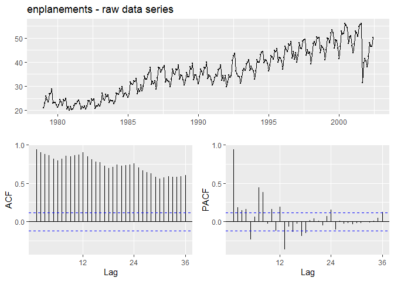

```r
ggtsdisplay(enplanements, main = "enplanements - raw data series")
```

```r
# The graph of the raw data shows strong autocorrelation as well as seasonality.
```

#### Ljung-box test on raw data series:

```r
Box.test(enplanements, type = "Ljung-Box")
```

```
##
##  Box-Ljung test
##
## data:  enplanements
## X-squared = 249.22, df = 1, p-value < 2.2e-16
```

Because the p-value is low, the Null hypothesis is REJECTED in factor of the alternative (Autocorrelation exists.)

#### Try Box-Cox transformation:

```r
enplanements_lambda <- round(BoxCox.lambda(enplanements),5)
print(paste("Lambda for enplanements: ", enplanements_lambda))
```

```
## [1] "Lambda for enplanements:  -0.22695"
```

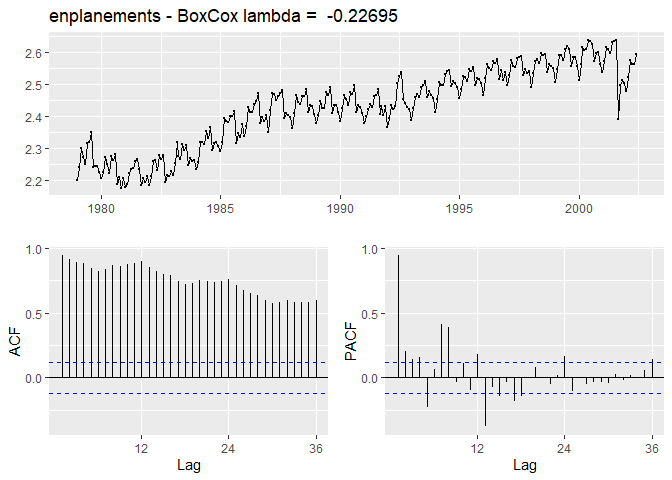

```r
enplanements_BC <- BoxCox(enplanements, enplanements_lambda)

ggtsdisplay(enplanements_BC, main = paste("enplanements - BoxCox lambda = ",
                                          enplanements_lambda))
```

The graph of the Box-Cox transformed data still shows strong autocorrelation and seasonality, but the variance has been dampened.

```r
Box.test(enplanements_BC, type = "Ljung-Box")
```

```
##
##  Box-Ljung test
##
## data:  enplanements_BC
## X-squared = 253.7, df = 1, p-value < 2.2e-16
```

Because the p-value is still low, the Null hypothesis is again REJECTED in factor of the alternative (Autocorrelation exists.)

#### Check estimated number of differences needed:

```r
enplanements_nsdiffs <- nsdiffs(enplanements)
print(paste("Number of SEASONAL differences suggested for enplanements (raw data):",
            enplanements_nsdiffs))
```

```
## [1] "Number of SEASONAL differences suggested for enplanements (raw data): 1"
```

```r
enplanements_ndiffs <- ndiffs(enplanements)
print(paste("Number of differences suggested for enplanements (raw data):",
            enplanements_ndiffs))
```

```
## [1] "Number of differences suggested for enplanements (raw data): 1"
```

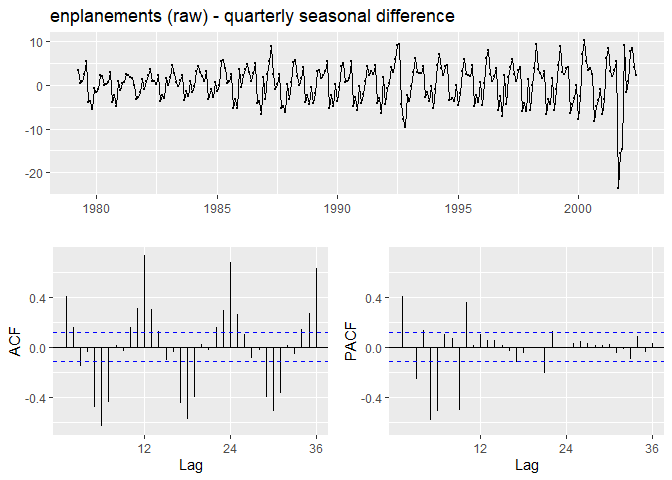

```r
ggtsdisplay(diff(enplanements,lag=3),
            main=paste("enplanements (raw) - quarterly seasonal difference"))
```

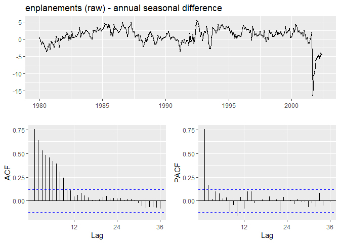

```r
ggtsdisplay(diff(enplanements,lag=12),
            main=paste("enplanements (raw) - annual seasonal difference"))
```

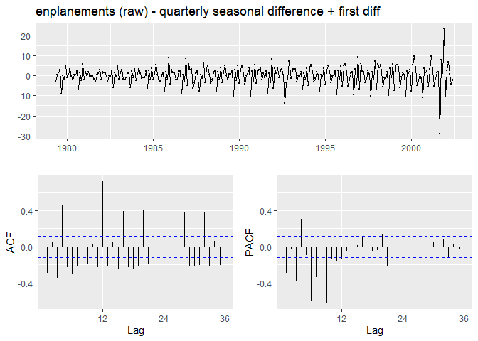

```r
ggtsdisplay(diff(diff(enplanements,lag=3),lag=1),
            main=paste("enplanements (raw) - quarterly seasonal difference + first diff"))
```

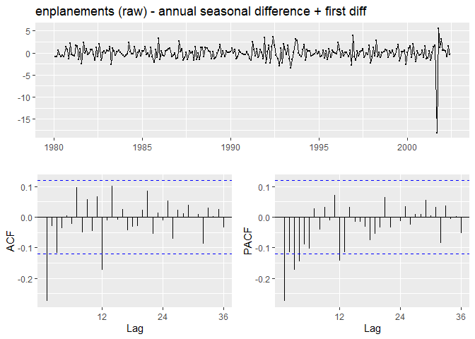

```r
ggtsdisplay(diff(diff(enplanements,lag=12),lag=1),
            main=paste("enplanements (raw) - annual seasonal difference + first diff"))
```

The graphs show that differencing without the Box-Cox transformation is not adequate to achieve stationarit

#### Check differences estimated for the Box-Cox transformed series:

```r
enplanements_BC_nsdiffs <- nsdiffs(enplanements_BC)
print(paste("Number of SEASONAL differences suggested for enplanements_BC:", enplanements_BC_nsdiffs))
```

```
## [1] "Number of SEASONAL differences suggested for enplanements_BC: 1"
```

```r
enplanements_BC_ndiffs <- ndiffs(enplanements_BC)
print(paste("Number of differences suggested for enplanements_BC:",
            enplanements_BC_ndiffs))
```

```
## [1] "Number of differences suggested for enplanements_BC: 1"
```

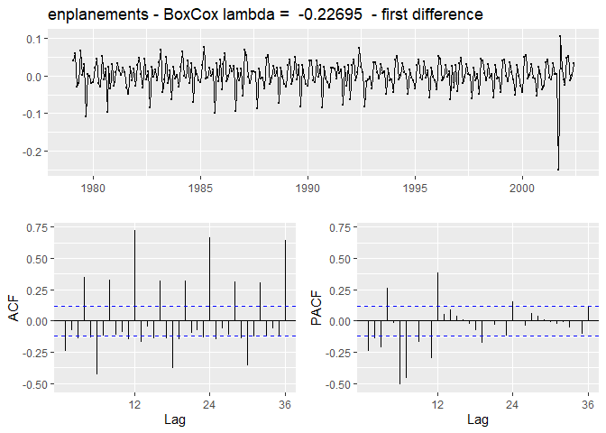

```r
ggtsdisplay(diff(enplanements_BC),
            main=paste("enplanements - BoxCox lambda = ",
                       enplanements_lambda," - first difference"))
```

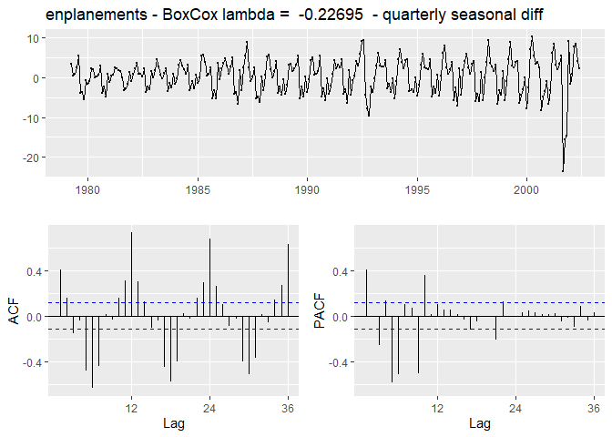

```r
ggtsdisplay(diff(enplanements,lag=3),
            main=paste("enplanements - BoxCox lambda = ",
                       enplanements_lambda," - quarterly seasonal diff"))
```

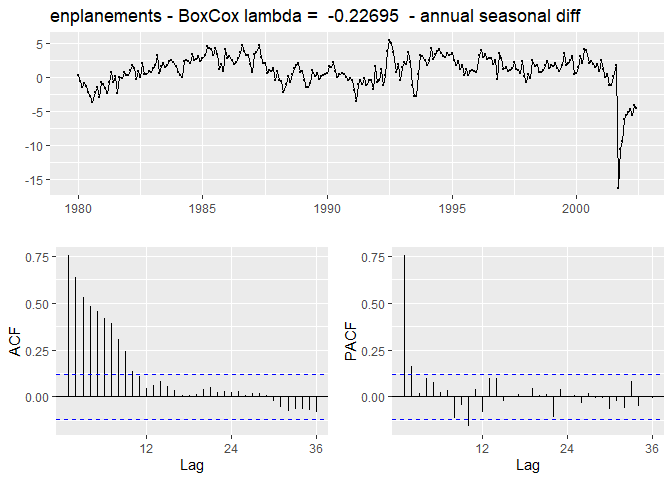

```r
ggtsdisplay(diff(enplanements,lag=12),
            main=paste("enplanements - BoxCox lambda = ",
                       enplanements_lambda," - annual seasonal diff"))
```

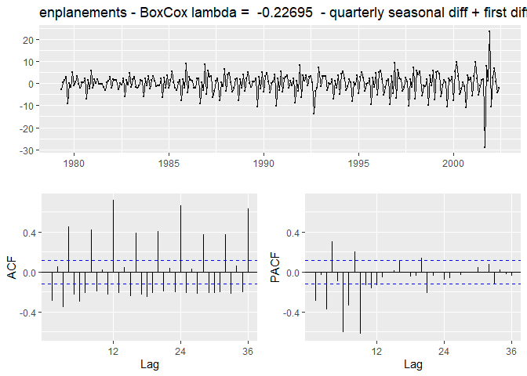

```r
ggtsdisplay(diff(diff(enplanements,lag=3),lag=1),
            main=paste("enplanements - BoxCox lambda = ",
                       enplanements_lambda," - quarterly seasonal diff + first diff"))
```

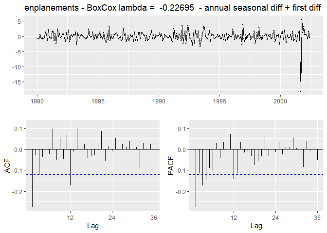

```r
ggtsdisplay(diff(diff(enplanements,lag=12),lag=1),
            main=paste("enplanements - BoxCox lambda = ",
                       enplanements_lambda," - annual seasonal diff + first diff"))
```

The “nsdiffs” and “ndiffs” functions indicate that seasonal differencing is required.  
Above, both quarterly and annual seasonality have been examined.

The raw data series and the Box-Cox transformed series each require 1 diff.

#### Let’s evaluate first differencing:

#### Diff data series:

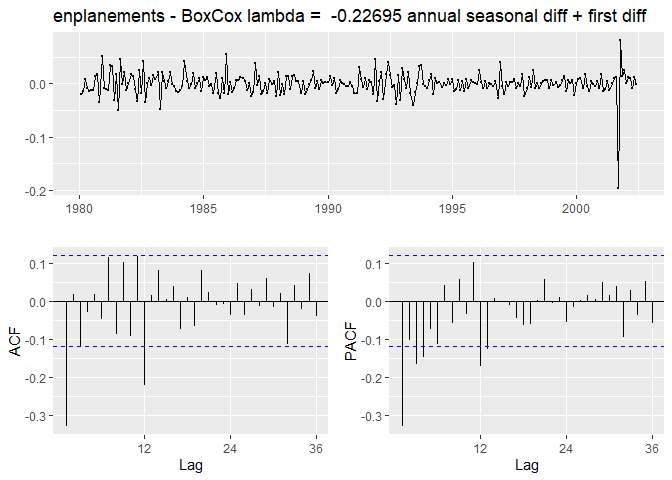

```r
enplanements_BC %>% diff(lag=12) %>% diff(lag=1) -> enplanements_BC_s1_d1
ggtsdisplay(enplanements_BC_s1_d1,
            main = paste("enplanements - BoxCox lambda = ",
                         enplanements_lambda, "annual seasonal diff + first diff"))
```

The first differenced series shows autocorrelation on lags 1, and a few of the subsequent lags breach the critical value.

#### Ljung-box test:

```r
Box.test(enplanements_BC_s1_d1, type = "Ljung-Box")
```

```
##
##  Box-Ljung test
##
## data:  enplanements_BC_s1_d1
## X-squared = 29.562, df = 1, p-value = 5.417e-08
```

Because the p-value is low, the Null hypothesis is REJECTED in factor of the alternative (Autocorrelation exists.)

#### Kwiatkowski-Phillips-Schmidt-Shin (KPSS) test:

```r
kpss.test(enplanements, "Level", lshort = F)
```

```
##
##  KPSS Test for Level Stationarity
##
## data:  enplanements
## KPSS Level = 1.7486, Truncation lag parameter = 15, p-value = 0.01
```

```r
kpss.test(enplanements, "Trend", lshort = F)
```

```
##
##  KPSS Test for Trend Stationarity
##
## data:  enplanements
## KPSS Trend = 0.070584, Truncation lag parameter = 15, p-value = 0.1
```

```r
enplanements %>% ur.kpss(type="mu", lags="long") %>% summary()
```

```
##
## #######################
## # KPSS Unit Root Test #
## #######################
##
## Test is of type: mu with 15 lags.
##
## Value of test-statistic is: 1.7486
##
## Critical value for a significance level of:
##                 10pct  5pct 2.5pct  1pct
## critical values 0.347 0.463  0.574 0.739
```

```r
enplanements %>% ur.kpss(type="tau", lags="long") %>% summary()
```

```
##
## #######################
## # KPSS Unit Root Test #
## #######################
##
## Test is of type: tau with 15 lags.
##
## Value of test-statistic is: 0.0706
##
## Critical value for a significance level of:
##                 10pct  5pct 2.5pct  1pct
## critical values 0.119 0.146  0.176 0.216
```

##### The KPSS tests on the raw data series fail on Level, but pass on Trend

```r
kpss.test(enplanements_BC, "Level", lshort = F)
```

```
##
##  KPSS Test for Level Stationarity
##
## data:  enplanements_BC
## KPSS Level = 1.714, Truncation lag parameter = 15, p-value = 0.01
```

```r
kpss.test(enplanements_BC, "Trend", lshort = F)
```

```
##
##  KPSS Test for Trend Stationarity
##
## data:  enplanements_BC
## KPSS Trend = 0.18061, Truncation lag parameter = 15, p-value = 0.02327
```

```r
enplanements_BC %>% ur.kpss(type="mu", lags="long") %>% summary()
```

```
##
## #######################
## # KPSS Unit Root Test #
## #######################
##
## Test is of type: mu with 15 lags.
##
## Value of test-statistic is: 1.714
##
## Critical value for a significance level of:
##                 10pct  5pct 2.5pct  1pct
## critical values 0.347 0.463  0.574 0.739
```

```r
enplanements_BC %>% ur.kpss(type="tau", lags="long") %>% summary()
```

```
##
## #######################
## # KPSS Unit Root Test #
## #######################
##
## Test is of type: tau with 15 lags.
##
## Value of test-statistic is: 0.1806
##
## Critical value for a significance level of:
##                 10pct  5pct 2.5pct  1pct
## critical values 0.119 0.146  0.176 0.216
```

##### Both KPSS tests fail on Box Cox transformed data series

```r
kpss.test(enplanements_BC_s1_d1, "Level", lshort = F)
```

```
##
##  KPSS Test for Level Stationarity
##
## data:  enplanements_BC_s1_d1
## KPSS Level = 0.074682, Truncation lag parameter = 15, p-value = 0.1
```

```r
kpss.test(enplanements_BC_s1_d1, "Trend", lshort = F)
```

```
##
##  KPSS Test for Trend Stationarity
##
## data:  enplanements_BC_s1_d1
## KPSS Trend = 0.03852, Truncation lag parameter = 15, p-value = 0.1
```

```r
enplanements_BC_s1_d1 %>% ur.kpss(type="mu", lags="long") %>% summary()
```

```
##
## #######################
## # KPSS Unit Root Test #
## #######################
##
## Test is of type: mu with 15 lags.
##
## Value of test-statistic is: 0.0747
##
## Critical value for a significance level of:
##                 10pct  5pct 2.5pct  1pct
## critical values 0.347 0.463  0.574 0.739
```

```r
enplanements_BC_s1_d1 %>% ur.kpss(type="tau", lags="long") %>% summary()
```

```
##
## #######################
## # KPSS Unit Root Test #
## #######################
##
## Test is of type: tau with 15 lags.
##
## Value of test-statistic is: 0.0385
##
## Critical value for a significance level of:
##                 10pct  5pct 2.5pct  1pct
## critical values 0.119 0.146  0.176 0.216
```

##### Both KPSS tests pass for the data series which has been transformed by annual seasonality and first differences.

### e) **visitors**

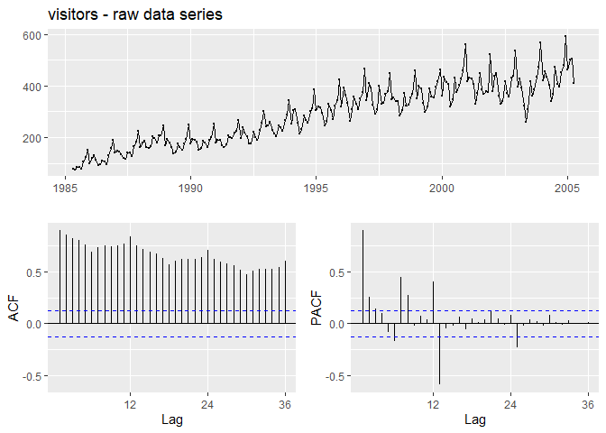

```r
ggtsdisplay(visitors, main = "visitors - raw data series")
```

```r
# The graph of the raw data shows strong autocorrelation as well as seasonality.
```

#### Ljung-box test on raw data series:

```r
Box.test(visitors, type = "Ljung-Box")
```

```
##
##  Box-Ljung test
##
## data:  visitors
## X-squared = 195.64, df = 1, p-value < 2.2e-16
```

Because the p-value is low, the Null hypothesis is REJECTED in factor of the alternative (Autocorrelation exists.)

#### Try Box-Cox transformation:

```r
visitors_lambda <- round(BoxCox.lambda(visitors),5)
print(paste("Lambda for visitors: ", visitors_lambda))
```

```
## [1] "Lambda for visitors:  0.27752"
```

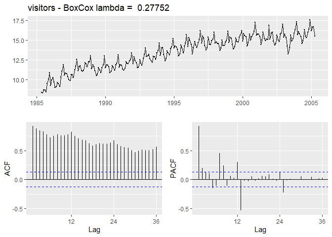

```r
visitors_BC <- BoxCox(visitors, visitors_lambda)

ggtsdisplay(visitors_BC, main = paste("visitors - BoxCox lambda = ",
                                          visitors_lambda))
```

The graph of the Box-Cox transformed data still shows strong autocorrelation and seasonality, but the variance has been dampened.

```r
Box.test(visitors_BC, type = "Ljung-Box")
```

```
##
##  Box-Ljung test
##
## data:  visitors_BC
## X-squared = 205.74, df = 1, p-value < 2.2e-16
```

Because the p-value is still low, the Null hypothesis is again REJECTED in factor of the alternative (Autocorrelation exists.)

#### Check estimated number of differences needed:

```r
visitors_nsdiffs <- nsdiffs(visitors)
print(paste("Number of SEASONAL differences suggested for visitors (raw data):",
            visitors_nsdiffs))
```

```
## [1] "Number of SEASONAL differences suggested for visitors (raw data): 1"
```

```r
visitors_ndiffs <- ndiffs(visitors)
print(paste("Number of differences suggested for visitors (raw data):",
            visitors_ndiffs))
```

```
## [1] "Number of differences suggested for visitors (raw data): 1"
```

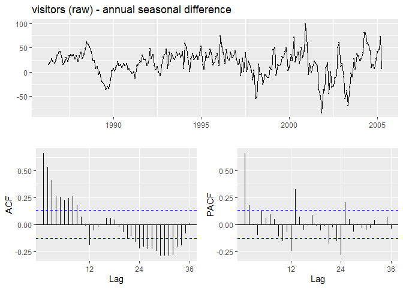

```r
ggtsdisplay(diff(visitors,lag=12),
            main=paste("visitors (raw) - annual seasonal difference"))
```

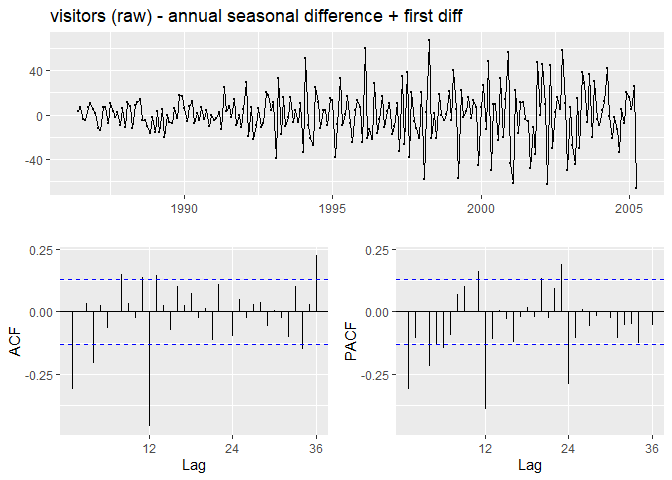

```r
ggtsdisplay(diff(diff(visitors,lag=12),lag=1),
            main=paste("visitors (raw) - annual seasonal difference + first diff"))
```

The graphs show that differencing without the Box-Cox transformation is not adequate to achieve stationarity

#### Check differences estimated for the Box-Cox transformed series:

```r
visitors_BC_nsdiffs <- nsdiffs(visitors_BC)
print(paste("Number of SEASONAL differences suggested for visitors_BC:", visitors_BC_nsdiffs))
```

```
## [1] "Number of SEASONAL differences suggested for visitors_BC: 1"
```

```r
visitors_BC_ndiffs <- ndiffs(visitors_BC)
print(paste("Number of differences suggested for visitors_BC:",
            visitors_BC_ndiffs))
```

```
## [1] "Number of differences suggested for visitors_BC: 1"
```

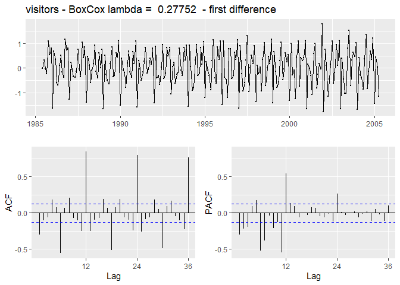

```r
ggtsdisplay(diff(visitors_BC),
            main=paste("visitors - BoxCox lambda = ",
                       visitors_lambda," - first difference"))
```

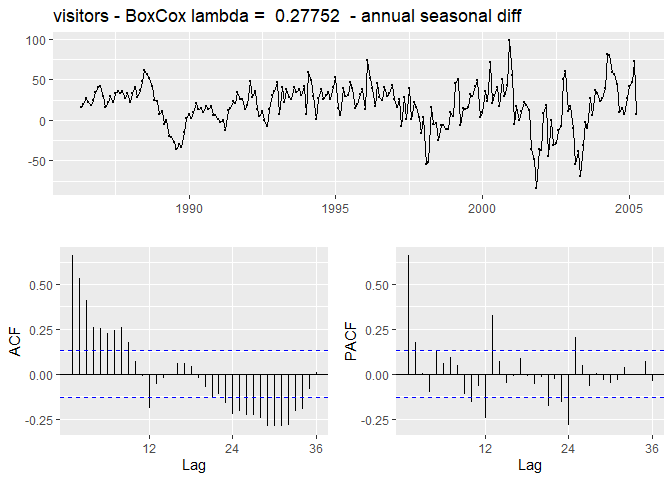

```r
ggtsdisplay(diff(visitors,lag=12),
            main=paste("visitors - BoxCox lambda = ",
                       visitors_lambda," - annual seasonal diff"))
```

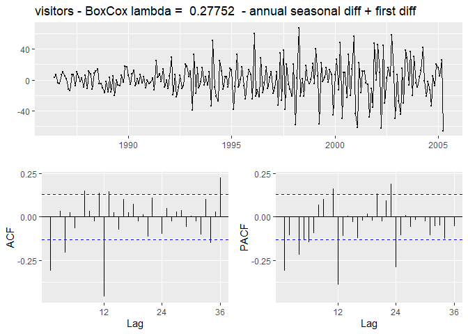

```r
ggtsdisplay(diff(diff(visitors,lag=12),lag=1),
            main=paste("visitors - BoxCox lambda = ",
                       visitors_lambda," - annual seasonal diff + first diff"))
```

The “nsdiffs” and “ndiffs” functions indicate that seasonal differencing is required.

The raw data series and the Box-Cox transformed series each require 1 diff.

The result of Box-Cox transformation, annual seasonal differencing, plus regular differencing, seems to provide the best result.

#### Let’s evaluate first differencing:

#### Diff data series:

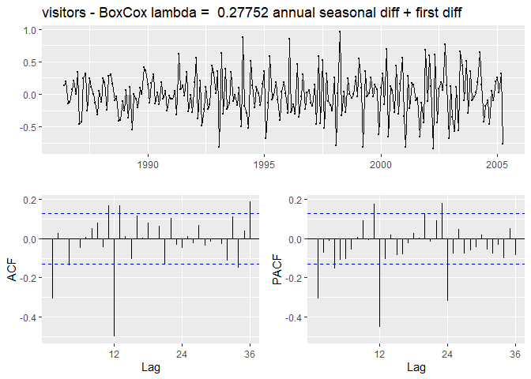

```r
visitors_BC %>% diff(lag=12) %>% diff(lag=1) -> visitors_BC_s1_d1
ggtsdisplay(visitors_BC_s1_d1,
            main = paste("visitors - BoxCox lambda = ",
                         visitors_lambda, "annual seasonal diff + first diff"))
```

The first differenced series shows autocorrelation on lags 1, and a few of the subsequent lags breach the critical value.

#### Ljung-box test:

```r
Box.test(visitors_BC_s1_d1, type = "Ljung-Box")
```

```
##
##  Box-Ljung test
##
## data:  visitors_BC_s1_d1
## X-squared = 21.804, df = 1, p-value = 3.02e-06
```

Because the p-value is low, the Null hypothesis is REJECTED in factor of the alternative (Autocorrelation exists.)

#### Kwiatkowski-Phillips-Schmidt-Shin (KPSS) test:

```r
kpss.test(visitors, "Level", lshort = F)
```

```
##
##  KPSS Test for Level Stationarity
##
## data:  visitors
## KPSS Level = 1.6864, Truncation lag parameter = 14, p-value = 0.01
```

```r
kpss.test(visitors, "Trend", lshort = F)
```

```
##
##  KPSS Test for Trend Stationarity
##
## data:  visitors
## KPSS Trend = 0.15852, Truncation lag parameter = 14, p-value = 0.03956
```

```r
visitors %>% ur.kpss(type="mu", lags="long") %>% summary()
```

```
##
## #######################
## # KPSS Unit Root Test #
## #######################
##
## Test is of type: mu with 14 lags.
##
## Value of test-statistic is: 1.6864
##
## Critical value for a significance level of:
##                 10pct  5pct 2.5pct  1pct
## critical values 0.347 0.463  0.574 0.739
```

```r
visitors %>% ur.kpss(type="tau", lags="long") %>% summary()
```

```
##
## #######################
## # KPSS Unit Root Test #
## #######################
##
## Test is of type: tau with 14 lags.
##
## Value of test-statistic is: 0.1585
##
## Critical value for a significance level of:
##                 10pct  5pct 2.5pct  1pct
## critical values 0.119 0.146  0.176 0.216
```

##### Both KPSS tests fail on the raw data series

```r
kpss.test(visitors_BC, "Level", lshort = F)
```

```
##
##  KPSS Test for Level Stationarity
##
## data:  visitors_BC
## KPSS Level = 1.652, Truncation lag parameter = 14, p-value = 0.01
```

```r
kpss.test(visitors_BC, "Trend", lshort = F)
```

```
##
##  KPSS Test for Trend Stationarity
##
## data:  visitors_BC
## KPSS Trend = 0.28285, Truncation lag parameter = 14, p-value = 0.01
```

```r
visitors_BC %>% ur.kpss(type="mu", lags="long") %>% summary()
```

```
##
## #######################
## # KPSS Unit Root Test #
## #######################
##
## Test is of type: mu with 14 lags.
##
## Value of test-statistic is: 1.652
##
## Critical value for a significance level of:
##                 10pct  5pct 2.5pct  1pct
## critical values 0.347 0.463  0.574 0.739
```

```r
visitors_BC %>% ur.kpss(type="tau", lags="long") %>% summary()
```

```
##
## #######################
## # KPSS Unit Root Test #
## #######################
##
## Test is of type: tau with 14 lags.
##
## Value of test-statistic is: 0.2828
##
## Critical value for a significance level of:
##                 10pct  5pct 2.5pct  1pct
## critical values 0.119 0.146  0.176 0.216
```

##### Both KPSS tests fail on Box Cox transformed data series

```r
kpss.test(visitors_BC_s1_d1, "Level", lshort = F)
```

```
##
##  KPSS Test for Level Stationarity
##
## data:  visitors_BC_s1_d1
## KPSS Level = 0.032281, Truncation lag parameter = 14, p-value = 0.1
```

```r
kpss.test(visitors_BC_s1_d1, "Trend", lshort = F)
```

```
##
##  KPSS Test for Trend Stationarity
##
## data:  visitors_BC_s1_d1
## KPSS Trend = 0.032061, Truncation lag parameter = 14, p-value = 0.1
```

```r
visitors_BC_s1_d1 %>% ur.kpss(type="mu", lags="long") %>% summary()
```

```
##
## #######################
## # KPSS Unit Root Test #
## #######################
##
## Test is of type: mu with 14 lags.
##
## Value of test-statistic is: 0.0323
##
## Critical value for a significance level of:
##                 10pct  5pct 2.5pct  1pct
## critical values 0.347 0.463  0.574 0.739
```

```r
visitors_BC_s1_d1 %>% ur.kpss(type="tau", lags="long") %>% summary()
```

```
##
## #######################
## # KPSS Unit Root Test #
## #######################
##
## Test is of type: tau with 14 lags.
##
## Value of test-statistic is: 0.0321
##
## Critical value for a significance level of:
##                 10pct  5pct 2.5pct  1pct
## critical values 0.119 0.146  0.176 0.216
```

##### Both KPSS tests pass for the data series which has been transformed by annual seasonality and first differences.

## 8.5 For your `retail` data (from Exercise 3 in Section 2.10), find the appropriate order of differencing (after transformation if necessary) to obtain stationary data.

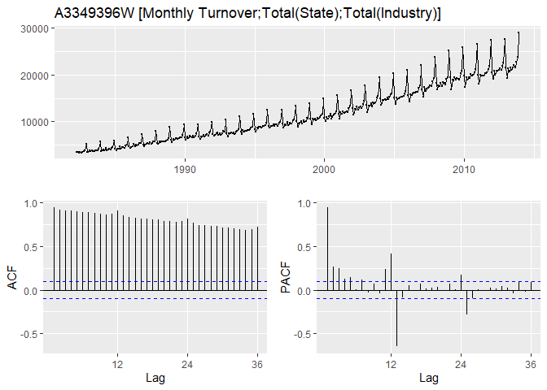

```r
mycode <- "A3349396W"
mytitle <-  "[Monthly Turnover;Total(State);Total(Industry)]"
mymain <- paste(mycode,mytitle)
myts <- readxl::read_excel("retail.xlsx", skip=1)[,mycode] %>%
  ts(frequency=12, start=c(1982,4))

ggtsdisplay(myts,main=mymain)
```

```r
Box.test(myts, type = "Ljung-Box")
```

```
##
##  Box-Ljung test
##
## data:  myts
## X-squared = 343.06, df = 1, p-value < 2.2e-16
```

#### Kwiatkowski-Phillips-Schmidt-Shin (KPSS) test:

```r
kpss.test(myts, "Level", lshort = F)
```

```
##
##  KPSS Test for Level Stationarity
##
## data:  myts
## KPSS Level = 2.2987, Truncation lag parameter = 16, p-value = 0.01
```

```r
kpss.test(myts, "Trend", lshort = F)
```

```
##
##  KPSS Test for Trend Stationarity
##
## data:  myts
## KPSS Trend = 0.56755, Truncation lag parameter = 16, p-value = 0.01
```

```r
myts %>% ur.kpss(type="mu", lags="long") %>% summary()
```

```
##
## #######################
## # KPSS Unit Root Test #
## #######################
##
## Test is of type: mu with 16 lags.
##
## Value of test-statistic is: 2.2987
##
## Critical value for a significance level of:
##                 10pct  5pct 2.5pct  1pct
## critical values 0.347 0.463  0.574 0.739
```

```r
myts %>% ur.kpss(type="tau", lags="long") %>% summary()
```

```
##
## #######################
## # KPSS Unit Root Test #
## #######################
##
## Test is of type: tau with 16 lags.
##
## Value of test-statistic is: 0.5676
##
## Critical value for a significance level of:
##                 10pct  5pct 2.5pct  1pct
## critical values 0.119 0.146  0.176 0.216
```

##### The KPSS tests on the raw data series fail on both Level and Trend

```r
myts_nsdiffs <- nsdiffs(myts)
print(paste("Number of SEASONAL differences suggested for",mymain,":", myts_nsdiffs))
```

```
## [1] "Number of SEASONAL differences suggested for A3349396W [Monthly Turnover;Total(State);Total(Industry)] : 1"
```

```r
myts_ndiffs <- ndiffs(myts)
print(paste("Number of SEASONAL differences suggested for",mymain,":", myts_ndiffs))
```

```
## [1] "Number of SEASONAL differences suggested for A3349396W [Monthly Turnover;Total(State);Total(Industry)] : 1"
```

#### Try Box-Cox transformation:

```r
myts_lambda <- round(BoxCox.lambda(myts),5)
print(paste("Lambda for",mymain,":", mcopper_lambda))
```

[output not shown]

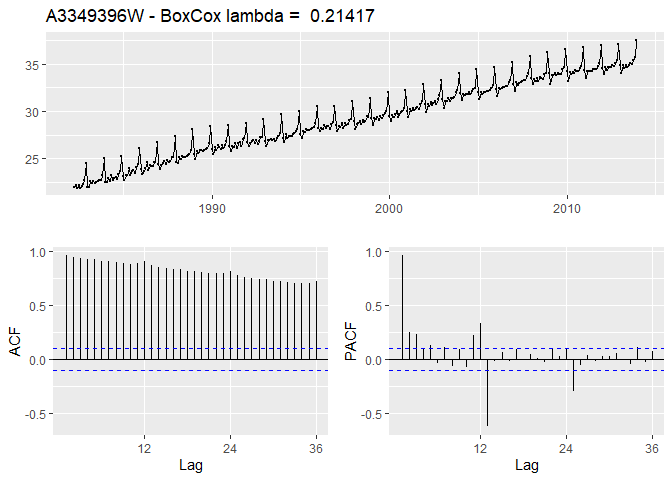

```r
myts_BC <- BoxCox(myts, myts_lambda)
mymain_BC <- paste(mycode,"- BoxCox lambda = ",myts_lambda)
ggtsdisplay(myts_BC, main = mymain_BC)
```

```r
Box.test(myts_BC, type = "Ljung-Box")
```

```
##
##  Box-Ljung test
##
## data:  myts_BC
## X-squared = 354.56, df = 1, p-value < 2.2e-16
```

```r
kpss.test(myts_BC, "Level", lshort = F)
```

```
##
##  KPSS Test for Level Stationarity
##
## data:  myts_BC
## KPSS Level = 2.3362, Truncation lag parameter = 16, p-value = 0.01
```

```r
kpss.test(myts_BC, "Trend", lshort = F)
```

```
##
##  KPSS Test for Trend Stationarity
##
## data:  myts_BC
## KPSS Trend = 0.13707, Truncation lag parameter = 16, p-value = 0.06654
```

```r
myts_BC %>% ur.kpss(type="mu", lags="long") %>% summary()
```

```
##
## #######################
## # KPSS Unit Root Test #
## #######################
##
## Test is of type: mu with 16 lags.
##
## Value of test-statistic is: 2.3362
##
## Critical value for a significance level of:
##                 10pct  5pct 2.5pct  1pct
## critical values 0.347 0.463  0.574 0.739
```

```r
myts_BC %>% ur.kpss(type="tau", lags="long") %>% summary()
```

```
##
## #######################
## # KPSS Unit Root Test #
## #######################
##
## Test is of type: tau with 16 lags.
##
## Value of test-statistic is: 0.1371
##
## Critical value for a significance level of:
##                 10pct  5pct 2.5pct  1pct
## critical values 0.119 0.146  0.176 0.216
```

##### The KPSS test on the Box Cox transformed data series fail on Level but pass on Trend.

```r
myts_BC_nsdiffs <- nsdiffs(myts_BC)
print(paste("Number of SEASONAL differences suggested for",mymain_BC,":", myts_BC_nsdiffs))
```

```
## [1] "Number of SEASONAL differences suggested for A3349396W - BoxCox lambda =  0.21417 : 1"
```

```r
myts_BC_ndiffs <- ndiffs(myts_BC)
print(paste("Number of SEASONAL differences suggested for",mymain_BC,":", myts_BC_ndiffs))
```

```
## [1] "Number of SEASONAL differences suggested for A3349396W - BoxCox lambda =  0.21417 : 1"
```

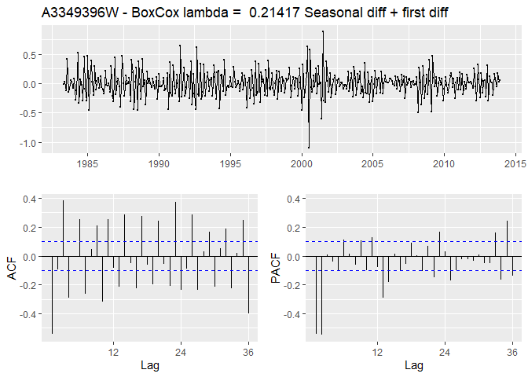

```r
myts_BC_s1_d1 <- myts_BC %>% diff(lag=12) %>% diff(lag=1)

mymain_BC_diffs <- paste(mymain_BC,"Seasonal diff + first diff")
ggtsdisplay(myts_BC_s1_d1,
            main=mymain_BC_diffs)
```

```r
kpss.test(myts_BC_s1_d1, "Level", lshort = F)
```

```
##
##  KPSS Test for Level Stationarity
##
## data:  myts_BC_s1_d1
## KPSS Level = 0.028024, Truncation lag parameter = 16, p-value = 0.1
```

```r
kpss.test(myts_BC_s1_d1, "Trend", lshort = F)
```

```
##
##  KPSS Test for Trend Stationarity
##
## data:  myts_BC_s1_d1
## KPSS Trend = 0.027518, Truncation lag parameter = 16, p-value = 0.1
```

```r
myts_BC_s1_d1 %>% ur.kpss(type="mu", lags="long") %>% summary()
```

```
##
## #######################
## # KPSS Unit Root Test #
## #######################
##
## Test is of type: mu with 16 lags.
##
## Value of test-statistic is: 0.028
##
## Critical value for a significance level of:
##                 10pct  5pct 2.5pct  1pct
## critical values 0.347 0.463  0.574 0.739
```

```r
myts_BC_s1_d1 %>% ur.kpss(type="tau", lags="long") %>% summary()
```

```
##
## #######################
## # KPSS Unit Root Test #
## #######################
##
## Test is of type: tau with 16 lags.
##
## Value of test-statistic is: 0.0275
##
## Critical value for a significance level of:
##                 10pct  5pct 2.5pct  1pct
## critical values 0.119 0.146  0.176 0.216
```

##### Both KPSS tests pass on annual seasonal + first differenced data series

## 8.6 Use R to simulate and plot some data from simple ARIMA models.

### a) Use the following R code to generate data from an AR(1) model

with $\phi_1=0.6$ and $\sigma^2=1$. The process starts with $y_1=0$.

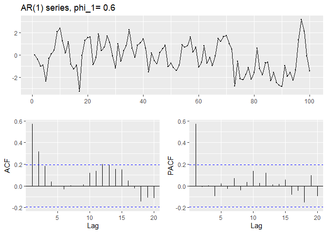

```r
AR1 <- function(phi)
{
  y <- ts(numeric(100))
  e <- rnorm(100)
  for(i in 2:100)
    y[i] <- phi*y[i-1] + e[i]
  return(y)
}

phi_1 <- 0.60
ggtsdisplay(AR1(phi_1),main=paste("AR(1) series, phi_1=",phi_1))
```

### b) Produce a time plot for the series. How does the plot change as you change $\phi_1$?

```r
set.seed(12345)
AR1_stats_results = numeric()
phi_seq <- seq(from=-1,to=1,by = 0.1)

for (phi_1 in phi_seq) {
  AR1_series <- AR1(phi_1)
  AR1_stats <- c(Phi_1 = phi_1, summary(AR1_series),StDev=sd(AR1_series),SdDiff=sd(diff(AR1_series)))
  AR1_main <- paste("AR(1) series, phi_1=",phi_1)
  ggtsdisplay(AR1_series,main=AR1_main)
  #print(AR1_stats)
  AR1_stats_results <- rbind(AR1_stats_results,AR1_stats)
}
```

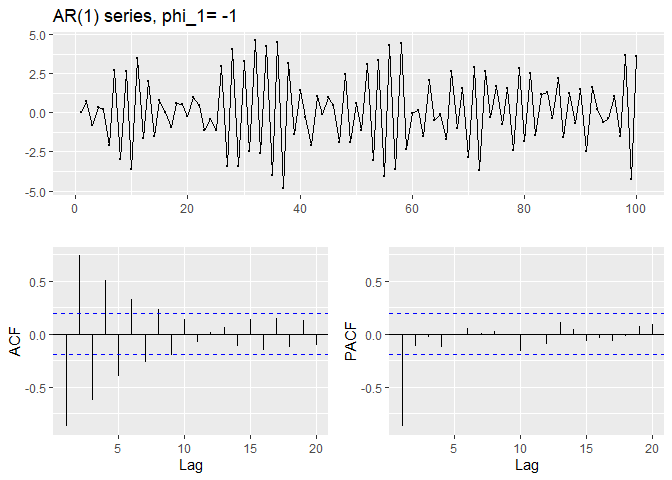

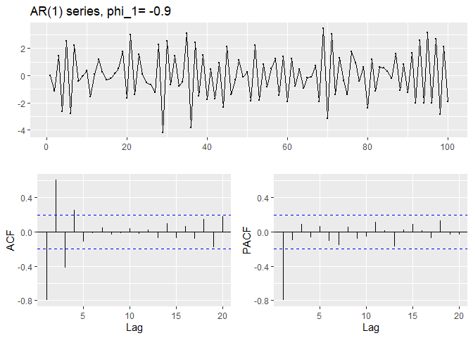

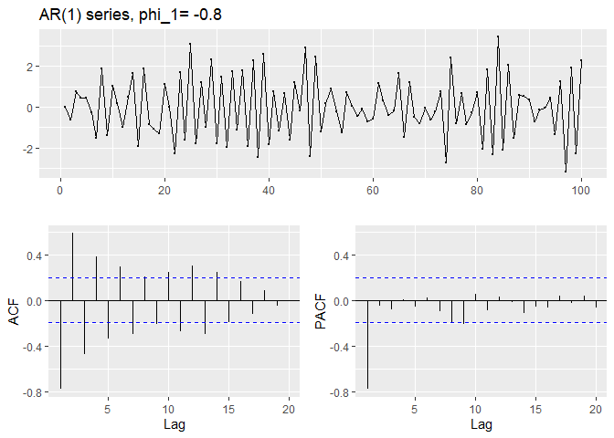

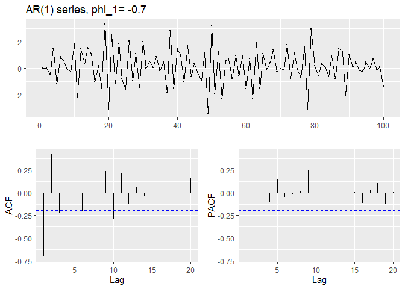

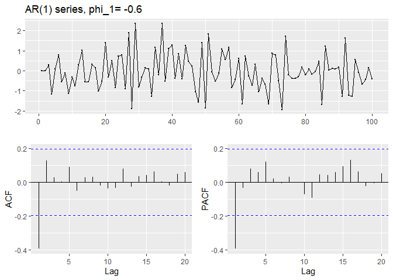

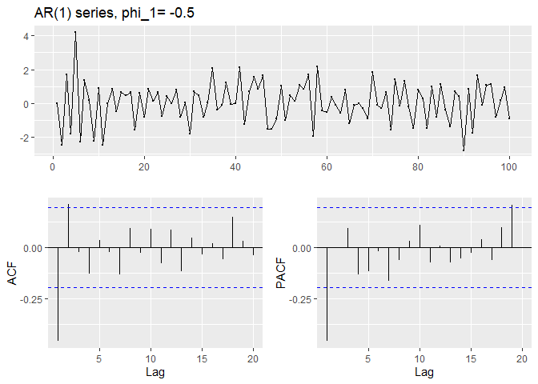

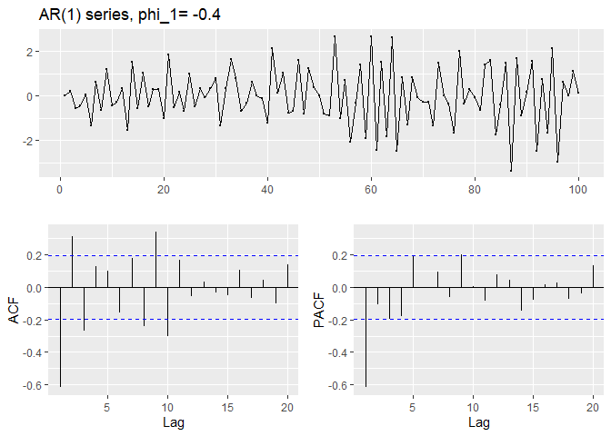

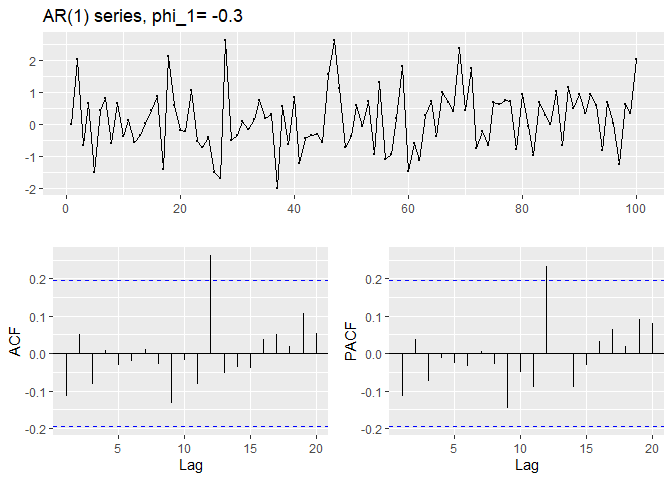

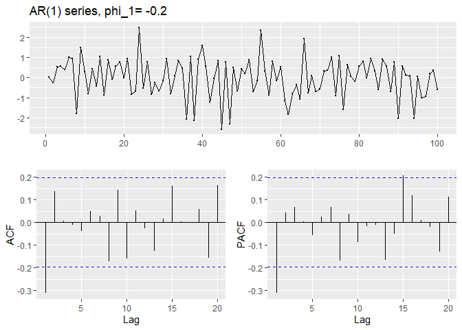

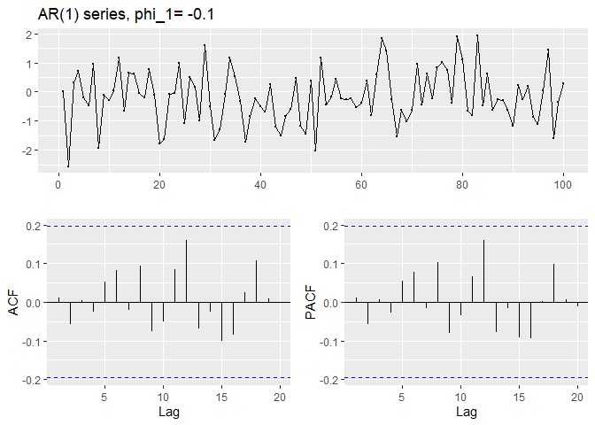

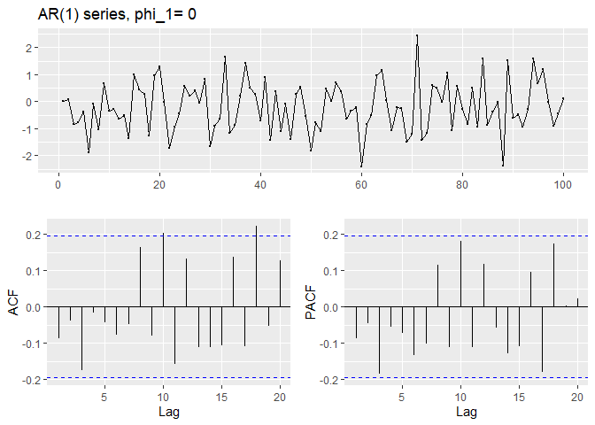

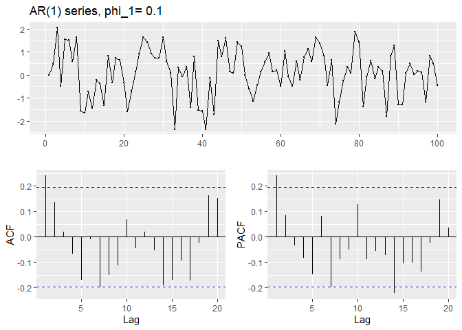

[9 more figures not shown]

```r
AR1_stats_results
```

```
##           Phi_1      Min.    1st Qu.       Median         Mean   3rd Qu.
## AR1_stats  -1.0 -4.810328 -1.5376074  0.025282049  0.137653162 1.7864250
## AR1_stats  -0.9 -4.158772 -1.3747743 -0.028912600  0.013688760 1.2591337
## AR1_stats  -0.8 -3.154382 -1.1887112 -0.077140387 -0.007503376 1.1200676
## AR1_stats  -0.7 -3.410915 -0.7810173  0.084770362  0.117672941 1.0720622
## AR1_stats  -0.6 -1.936819 -0.5516114 -0.103689483 -0.034933100 0.5488060
## AR1_stats  -0.5 -2.776452 -0.8055119  0.046569953  0.049196008 0.8492201
## AR1_stats  -0.4 -3.364833 -0.7039008 -0.008652004  0.007795845 0.8300460
## AR1_stats  -0.3 -1.989033 -0.5633470  0.153928011  0.149565675 0.6968589
## AR1_stats  -0.2 -2.578660 -0.7023718  0.091290686 -0.013764807 0.7590138
## AR1_stats  -0.1 -2.560052 -0.6760593 -0.238899537 -0.171245734 0.4731843
## AR1_stats   0.0 -2.402710 -0.8855039 -0.268306656 -0.201570142 0.4703282
## AR1_stats   0.1 -2.357408 -0.4635547  0.150371587  0.098657753 0.8104388
## AR1_stats   0.2 -2.229606 -0.6793502  0.090601453 -0.028728454 0.7184421
## AR1_stats   0.3 -3.449043 -0.9202869 -0.307662728 -0.278832152 0.3961435
## AR1_stats   0.4 -3.509097 -0.5253735  0.078577201  0.198240741 0.8810261
## AR1_stats   0.5 -2.225483 -1.0705274 -0.020806114 -0.128432926 0.6265709
## AR1_stats   0.6 -3.656013 -0.8997050 -0.114304599 -0.099464438 0.7050210
## AR1_stats   0.7 -4.371388 -0.5770992  0.213402964  0.097913167 0.9130002
## AR1_stats   0.8 -3.470953 -1.2666898 -0.419136558 -0.417538751 0.5820123
## AR1_stats   0.9 -3.998703 -0.3161399  0.754792592  0.754857980 2.1362739
## AR1_stats   1.0 -8.094175 -4.0404369 -1.632484191 -1.463852356 1.1023804
##               Max.     StDev   SdDiff
## AR1_stats 4.666069 2.3355689 4.532225
## AR1_stats 3.484262 1.6924696 3.223143
## AR1_stats 3.458808 1.4961145 2.826108
## AR1_stats 3.341460 1.3827348 2.563901
## AR1_stats 2.365774 0.9396446 1.577675
## AR1_stats 4.229266 1.2123269 2.077458
## AR1_stats 2.681672 1.2584885 2.275212
## AR1_stats 2.624459 0.9596337 1.427915
## AR1_stats 2.498753 0.9906810 1.612124
## AR1_stats 1.943005 0.9248660 1.306092
## AR1_stats 2.457074 0.9453084 1.400122
## AR1_stats 2.067448 1.0364809 1.282434
## AR1_stats 2.514284 1.0235093 1.263902
## AR1_stats 1.684784 0.9952520 1.273267
## AR1_stats 3.708281 1.1618359 1.192095
## AR1_stats 2.547435 1.1896935 1.214698
## AR1_stats 3.228343 1.2756715 1.097696
## AR1_stats 2.893791 1.2866680 1.150978
## AR1_stats 3.386849 1.4147713 1.026975
## AR1_stats 4.901704 1.9752239 1.046856
## AR1_stats 4.966340 3.2299537 1.005720
```

- When $\phi_1<0$, $y_t$ tends to oscillate around the mean.
- As $\phi_1$ becomes close to -1, the series oscillates more sharply, resulting in a higher standard deviation both of the series and of its changes
- When $\phi_1=0$, $y_t$ is equivalent to white noise.
- As $\phi_1$ increases toward 1, the standard deviation of the series increases, while the standard deviation of the changes moves closer to 1.
- when $\phi_1=1$, $y_t$ is equivalent to a random walk.